# Project 2

Magda Młynarczyk, Dariusz Matlak, Zuzanna Kasprowicz

# 1 Intorduction and preparing dataset

Our task is to analyze and understand data concerning Breast cancer cases. The dataset contains information about number of cancer cases for different regions, genders and age groups.

We were trying to consider the following:

1. Exploring the distribution of cases in different regions in different years.
2. Trying to normalize cases by the size of the population
3. Plot the cartogram for these cases.

We used libraries such as:

```r
library(data.table)
library(dplyr)
library(ggplot2)
library(lattice)
library(tidyr)
library(raster)
library(sp)
library(rgdal)
library(rgeos)
library(gdata)
library(maptools)
library(RColorBrewer)
library(png)
```

First we prepared dataset to make it more clear:

1. We removed first column (bacause the dataset is only about Breast cancer).
2. We changed the class of AGE-GROUP.
3. Finally we got data table: dt.

```r
head(dt)
```

```
##    GENDER TERYT4 region subregion year sumStage1 sumStage2 sumStage3
## 1:      K    201      2         1 2010      0.60      1.20      1.20
## 2:      K    201      2         1 2011      0.50      0.85      0.65
## 3:      K    201      2         1 2012      2.10      3.70      2.20
## 4:      K    202      2         2 2010      0.90      1.10      1.00
## 5:      K    202      2         2 2011      1.15      0.55      0.30
## 6:      K    202      2         2 2012      1.65      1.65      1.70
##    sumStage4 sumnew  AGE
## 1:         0      3 0-44
## 2:         1      3 0-44
## 3:         0      8 0-44
## 4:         0      3 0-44
## 5:         0      2 0-44
## 6:         0      5 0-44
```

# 2 The distribution of cases

In this chapter we will see some basic statistisc and information about the distribution of cases in different regions, years and in different age-group.

At first let’s look up the number of new cases of the breast cancer among different genders:

1.All:

```
## [1] 58118
```

2.Women:

```
## [1] 56748
```

3.Men:

```
## [1] 1370
```

Next, we want to present the distribution of new cases in different voivodeships and in different years: 2010, 2011, 2012:

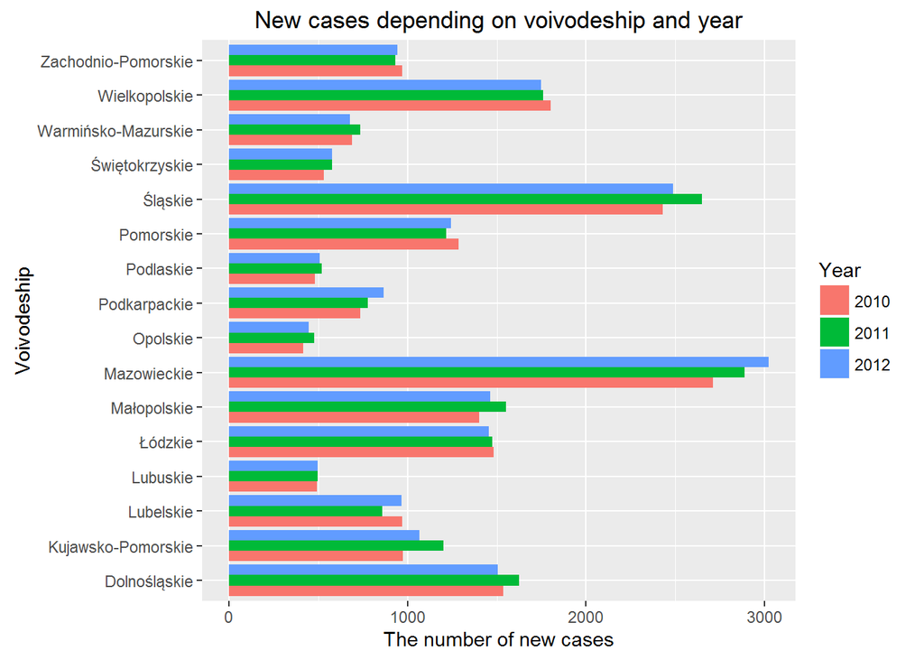

We can observe that the number of new cases, in each year, is the largest in voivodeships such as: Mazowieckie and Śląskie. Of course it strongly depends on the number of people who live in each voivodeship, but also there is also big impact of air and traffic pollution.The study links the risk of breast cancer – the second leading cause of death from cancer in women – to traffic-related air pollution. As we can find in GUS (Central Statistical Office) report the most contaminated voivodeships are: Mazowieckie, Śląskie and Wielkopolskie.

To confirm our conclusions, we prepare also normalized plot (the number of diseases in each voivodeship is divided into the total number of population in each voivodeship):

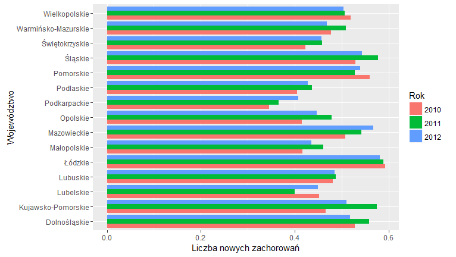

From above, we can also add Łódzkie and Pomorskie to the list of voivodeships with the largest number of breast diseases. Both Łódzkie and Pomorskie are also bit polluted voivodeships in Poland.

The following plot shows us the number of new cases depending on age-group and year:

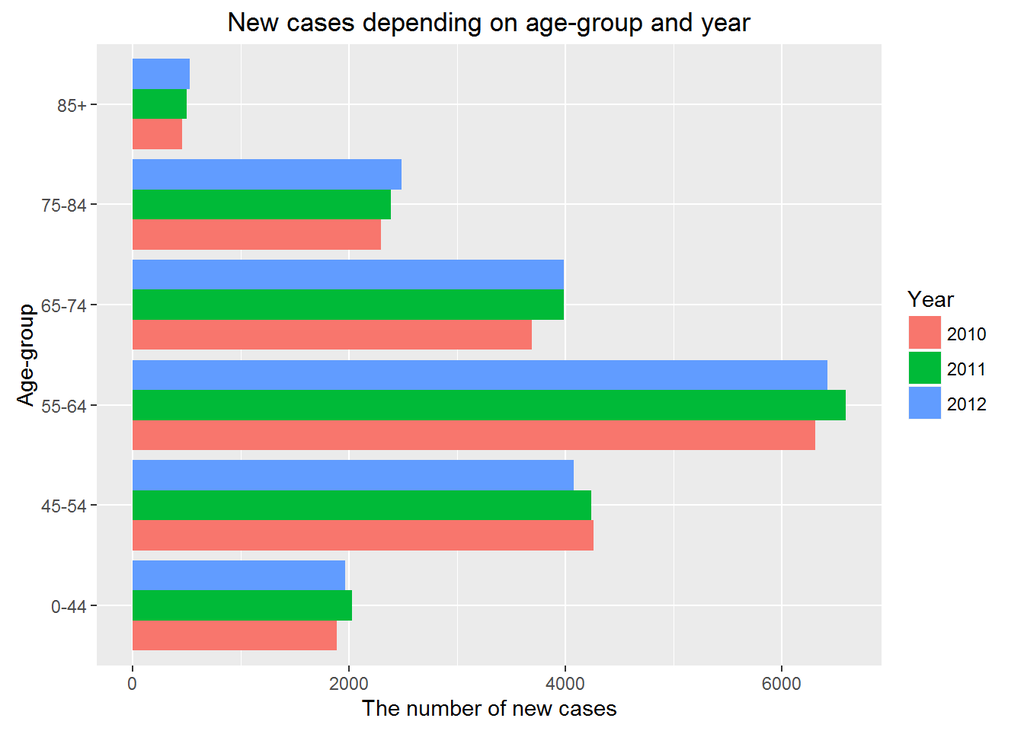

Next risk factor is emerging from above plot. It is an older age. We may notice that the quantity of new cases is the largest in 55-64 age-grouped.

Let’s see this data on different plots:

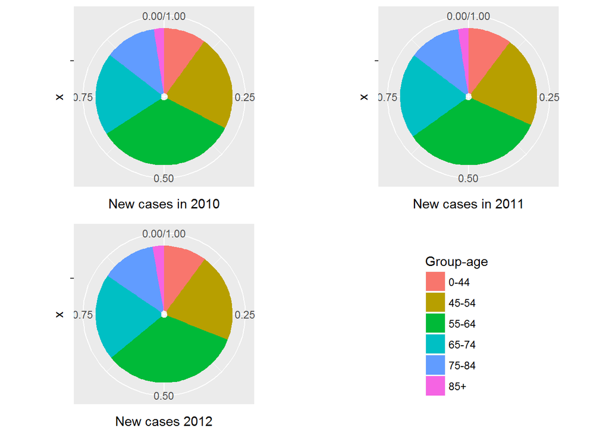

Now, we can clearly say that the number of new cases isn’t depend on year. It is very similar in 2010, 2011 and 2012.

The same data we can see in the table, which is more precise and we may see more:

1. In the first data-table, called analiza_reg, we can observe the number of diseases among women and man in different voivodeships:

```
##     region kobiety mezczyzni ogolem procent_mezczyzn
##  1:      2    4585        79   4664       0.01693825
##  2:      4    3200        41   3241       0.01265042
##  3:      6    2738        55   2793       0.01969209
##  4:      8    1460        23   1483       0.01550910
##  5:     10    4290       120   4410       0.02721088
##  6:     12    4315       105   4420       0.02375566
##  7:     14    8435       184   8619       0.02134818
##  8:     16    1319        22   1341       0.01640567
##  9:     18    2291        90   2381       0.03779924
## 10:     20    1467        44   1511       0.02911979
## 11:     22    3600       144   3744       0.03846154
## 12:     24    7348       215   7563       0.02842787
## 13:     26    1647        41   1688       0.02428910
## 14:     28    2041        58   2099       0.02763221
## 15:     30    5234        77   5311       0.01449821
## 16:     32    2778        72   2850       0.02526316
```

2. The second one shows us division into age-group, what’s more we can notice relative quantity of new cases in different age-group.

```
##     region 0-44 45-54 55-64 65-74 75-84 85+ ogolem    0-44_%  45-54_%
##  1:      2  445  1014  1621   887   573 124   4664  9.541166 21.74099
##  2:      4  340   732  1097   624   382  66   3241 10.490589 22.58562
##  3:      6  294   650   877   566   341  65   2793 10.526316 23.27247
##  4:      8  145   363   524   261   158  32   1483  9.777478 24.47741
##  5:     10  413   922  1568   911   492 104   4410  9.365079 20.90703
##  6:     12  449   966  1317   913   630 145   4420 10.158371 21.85520
##  7:     14  863  1728  2875  1764  1148 241   8619 10.012763 20.04873
##  8:     16  110   284   440   274   195  38   1341  8.202834 21.17823
##  9:     18  241   543   709   487   326  75   2381 10.121798 22.80554
## 10:     20  197   345   423   285   214  47   1511 13.037723 22.83256
## 11:     22  407   813  1190   773   454 107   3744 10.870726 21.71474
## 12:     24  711  1513  2551  1752   890 146   7563  9.401031 20.00529
## 13:     26  174   381   565   320   202  46   1688 10.308057 22.57109
## 14:     28  221   501   748   358   227  44   2099 10.528823 23.86851
```

[output cut: 19 more lines]

We can read for example that:

- the maximum number of diseases in voivodeships is:

```
## [1] 8619
```

and it is the voivodeship number:

```
##    region
## 1:     14
```

- the lowest number of cases in both genders is:

```
## [1] 1341
```

and it is in the voivodeship:

```
##    region
## 1:     16
```

- the largest percentage of men disease cases is in the region:

```
##    region
## 1:     22
```

and it is (in percentage):

```
## [1] 3.846154
```

# 3 Cartogram

Next step in visualization our data is to use cartogram. It is a thematic map in which areas are shaded or patterned in proportion to the measurement of the statistical variable being displayed on the map, such as population density or per-capita income. In our data we use it to show the number of new cases in counties.

Further considerances refer to female at all ages.

At the beggining let’s consider cartogram for counties. We split up dataset into three years and set 2010 year to plot cartogram. So we have:

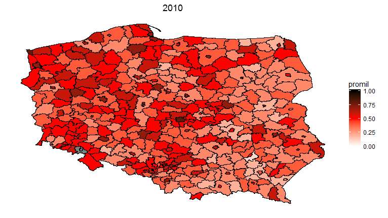

In general, we see that on the Southeast and the Northeast the number of cases is the lowest, but the biggest clusters of diseases are in region of Katowice, Łódź, Szczecin, Gdańsk and Warszawa. We can confirm it looking at the map from some research:

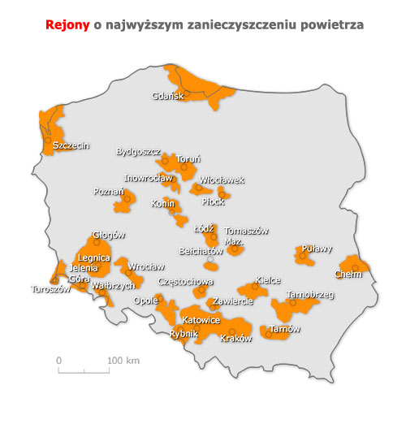

# 4 Appendix

As we noticed earlier, the division into years isn’t very noteworthy, but for interested in we present the cartogram also for the rest of the years:

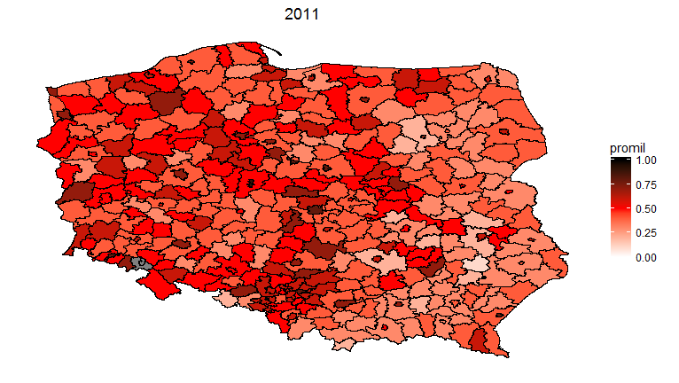

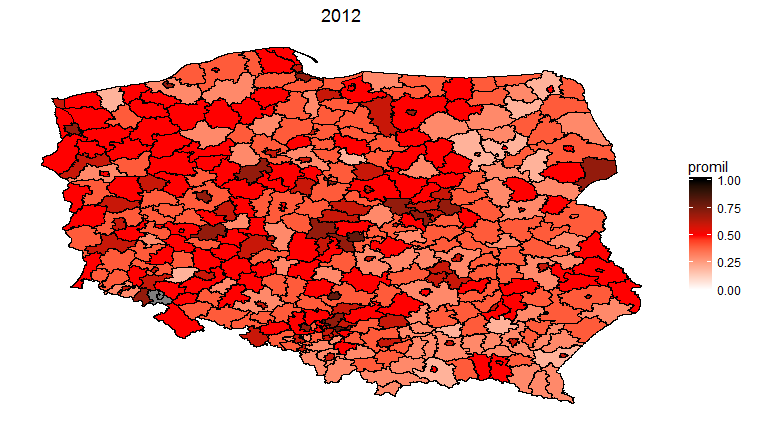

Because there is a number of different counties we decided to plot cartogram also for voivodeships - to make it more clear:

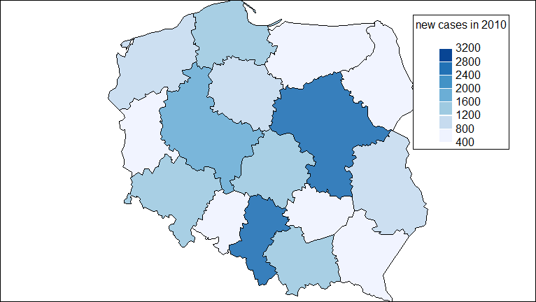

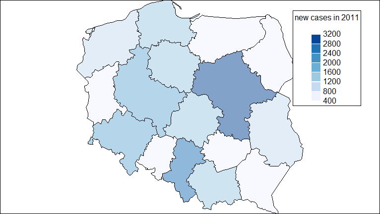

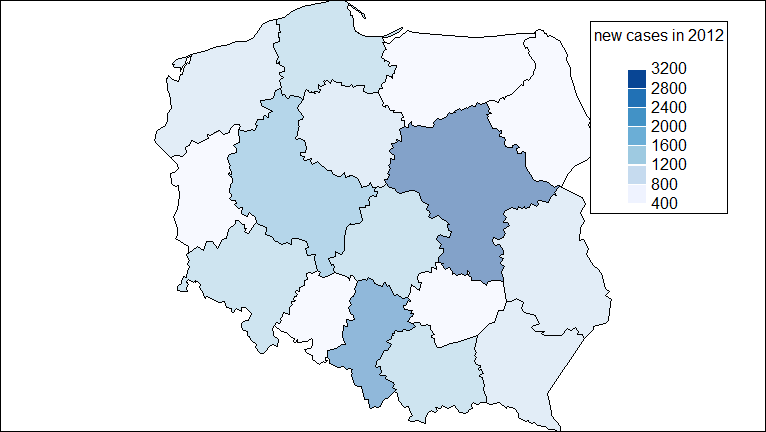

# 5 Bibliography

http://www.portalsamorzadowy.pl/ochrona-srodowiska/oto-najbardziej-zanieczyszczone-wojewodztwa-w-polsce,55990.html

https://www.sciencedaily.com/releases/2010/10/101006104003.htm

https://en.wikipedia.org/wiki/Breast_cancer

https://en.wikipedia.org/wiki/Choropleth_map

https://github.com/pbiecek/teryt

http://www.filtrywentylacja.pl/faq/zanieczyszczenia-powietrza-oddychac-zatrutym-powietrzem/

http://mapoland.r-forge.r-project.org

Patrick Brown, Simple and flexible maps of geospatial data with mapmisc, http://pbrown.ca/mapmisc/mapmisc.pdf